# Clustering Exercise: Customer Segmentation

Davide Proserpio

## 1 Load the Data

```r
f <- "customer_clustering_data.csv"
df <- fread(f)
head(df)
```

```
##    CustomerID   Age Income Online_Spend InStore_Spend
##         <int> <int>  <int>        <int>         <int>
## 1:          1    23  37241         1212           239
## 2:          2    24  35265         1073           181
## 3:          3    31  39611          584           520
## 4:          4    25  45250         1539           431
## 5:          5    26  32545          762           273
## 6:          6    32  23454         1422           354
```

```r
print(skim(df))
```

```
## ── Data Summary ────────────────────────
##                            Values
## Name                       df
## Number of rows             198
## Number of columns          5
## Key                        NULL
## _______________________
## Column type frequency:
##   numeric                  5
## ________________________
## Group variables            None
##
## ── Variable type: numeric ──────────────────────────────────────────────────────
##   skim_variable n_missing complete_rate    mean       sd    p0     p25     p50
## 1 CustomerID            0             1    99.5    57.3      1    50.2    99.5
## 2 Age                   0             1    35.4     9.92    17    27      34
## 3 Income                0             1 57681.  19976.   23454 37633.  58478.
## 4 Online_Spend          0             1  1169.    741.       1   502.   1088
## 5 InStore_Spend         0             1  1617.   1052.     147   356    1938
##      p75   p100 hist
## 1   149.    198 ▇▇▇▇▇
## 2    43      59 ▆▇▇▅▂
## 3 71885  105041 ▇▅▇▃▂
## 4  1648.   3475 ▇▇▅▃▁
## 5  2474.   3615 ▇▁▅▇▂
```

## 2 Quick EDA (Scatter & Distributions)

Let’s plot the scatter plot of Online vs In-Store Spend, income, and age distribution

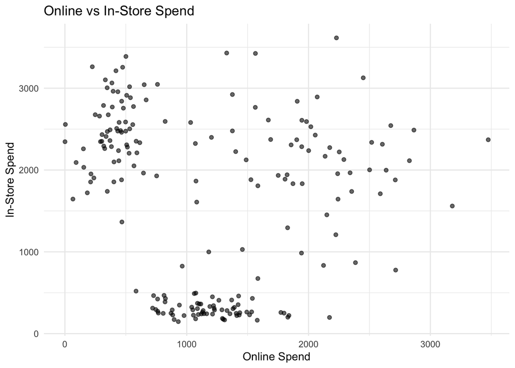

```r
p1 <- ggplot(df, aes(Online_Spend, InStore_Spend)) +
  geom_point(alpha = 0.6) +
  labs(title = "Online vs In-Store Spend", x = "Online Spend", y = "In-Store Spend") +
  theme_minimal()

p2 <- ggplot(df, aes(Income)) +
  geom_histogram(bins = 30, fill = "grey70", color = "white") +
  labs(title = "Income Distribution", x = "Income", y = "Count") +
  theme_minimal()

p3 <- ggplot(df, aes(Age)) +
  geom_histogram(bins = 30, fill = "grey70", color = "white") +
  labs(title = "Age Distribution", x = "Age", y = "Count") +
  theme_minimal()

p1
```

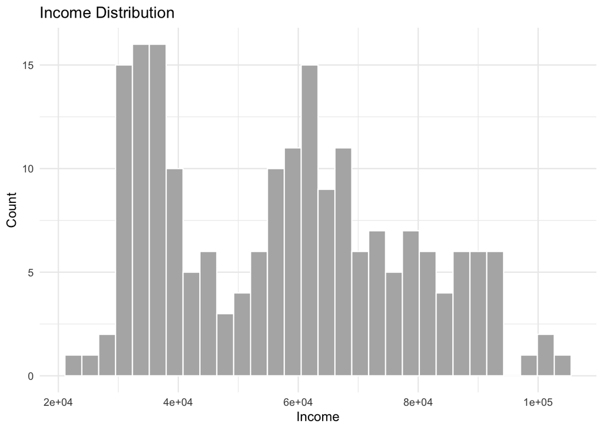

```r
p2
```

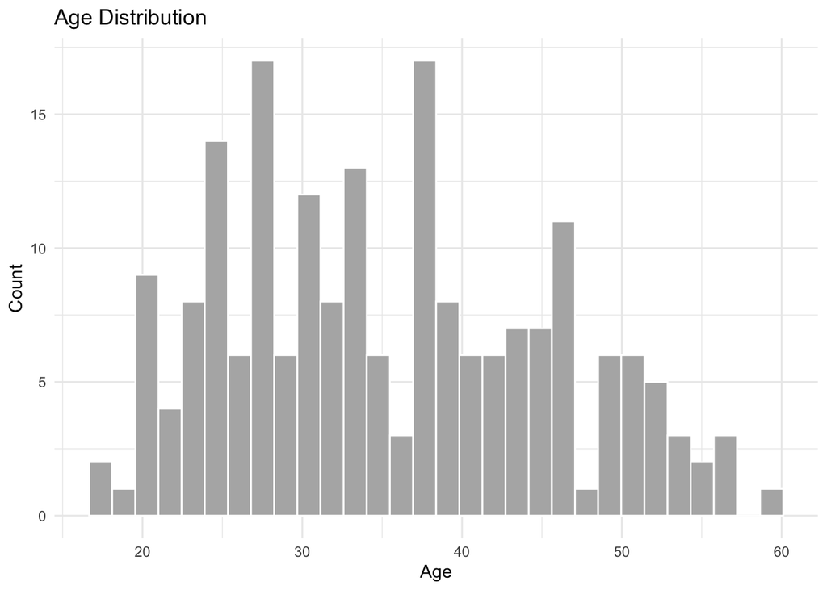

```r
p3
```

- Do you see natural groupings by spend/income/age (e.g., online-heavy, in-store-heavy, omni-channel)?

**SOLUTION:** Yes: clusters around high in-store / low online; high online / low in-store; and high both (omni-channel).

## 3 Prepare Features & Scale

```r
features <- df[, .(Online_Spend, InStore_Spend, Age, Income)]
X <- scale(features)  # mean=0, sd=1
summary(X)
```

```
##   Online_Spend     InStore_Spend          Age              Income
##  Min.   :-1.5776   Min.   :-1.3977   Min.   :-1.8528   Min.   :-1.71338
##  1st Qu.:-0.9005   1st Qu.:-1.1990   1st Qu.:-0.8447   1st Qu.:-1.00358
##  Median :-0.1099   Median : 0.3050   Median :-0.1390   Median : 0.03987
##  Mean   : 0.0000   Mean   : 0.0000   Mean   : 0.0000   Mean   : 0.00000
##  3rd Qu.: 0.6469   3rd Qu.: 0.8143   3rd Qu.: 0.7683   3rd Qu.: 0.71104
##  Max.   : 3.1130   Max.   : 1.8993   Max.   : 2.3813   Max.   : 2.37081
```

- Why do we scale before k-means?

**SOLUTION:** K-means uses Euclidean distance; unscaled high-variance features (Income/Spend) would dominate distance and clustering.

## 4 Choose k: Elbow Method (WSS)

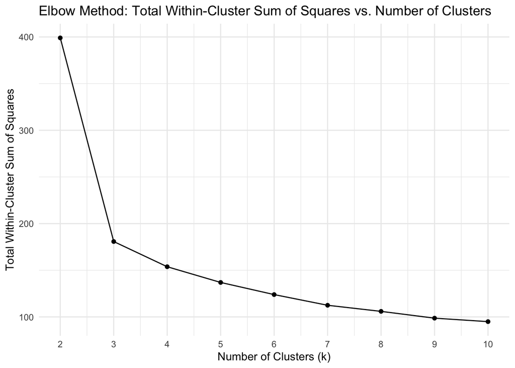

```r
wss <- sapply(2:10, function(k){
  kmeans(X, centers = k, nstart = 25)$tot.withinss
})
## plot the within-cluster sum of squares
elbow_plot <- data.frame(k = 2:10, wss = wss)
ggplot(elbow_plot, aes(x = k, y = wss)) +
  geom_line() +
  geom_point() +
  scale_x_continuous(breaks = 2:10) +
  labs(title = "Elbow Method: Total Within-Cluster Sum of Squares vs. Number of Clusters",
       x = "Number of Clusters (k)",
       y = "Total Within-Cluster Sum of Squares") +
  theme_minimal()
```

- Inspect the plot. Where is the “elbow”? Propose a k.

**SOLUTION** Elbow typically around k ≈ 3 for this dataset.

## 5 Fit K-means (k = 3)

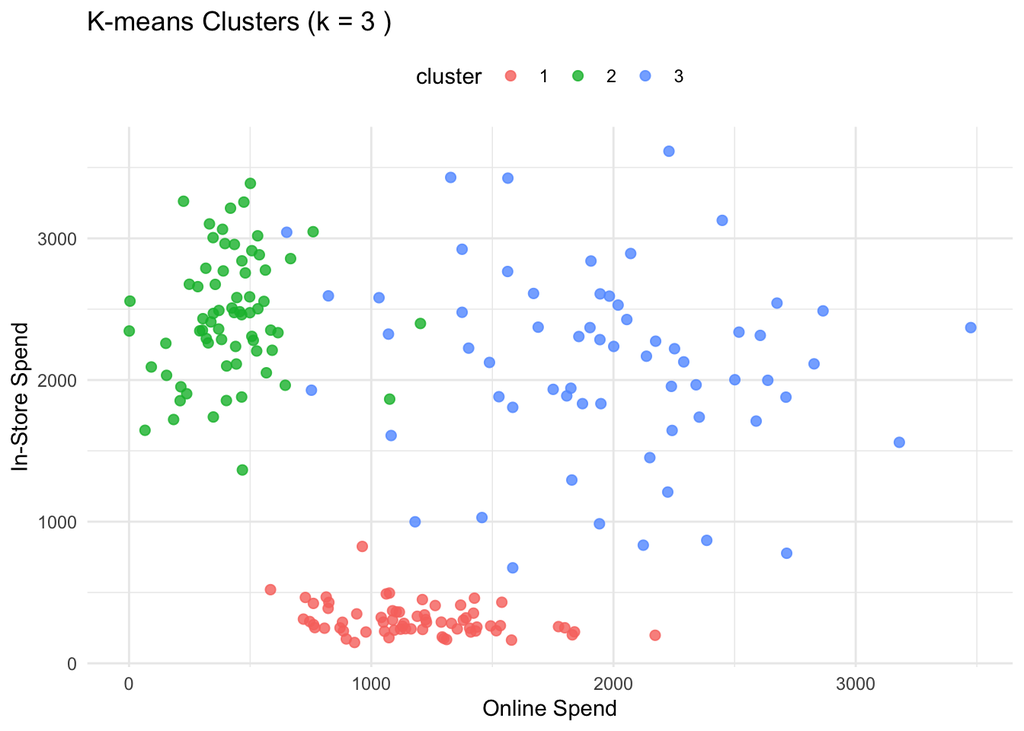

```r
k <- 3
km <- kmeans(X, centers = k, nstart = 50)

df$cluster <- factor(km$cluster)

# Cluster visualization in original spend space
ggplot(df, aes(Online_Spend, InStore_Spend, color = cluster)) +
  geom_point(size = 2, alpha = 0.8) +
  labs(title = paste("K-means Clusters (k =", k, ")"),
       x = "Online Spend", y = "In-Store Spend") +
  theme_minimal() +
  theme(legend.position = "top")
```

- What business personas do these clusters represent?

**SOLUTION** (1) Online-heavy low in-store; (2) In-store-heavy low online; (3) High both (omni-channel, likely highest value).

## 6 Cluster Profiling (Means by Cluster)

```r
profile = df[, .(Online_Spend = mean(Online_Spend),
                 InStore_Spend = mean(InStore_Spend),
                 Age = mean(Age),
                 Income = mean(Income)),
             by = cluster]
profile
```

```
##    cluster Online_Spend InStore_Spend      Age   Income
##     <fctr>        <num>         <num>    <num>    <num>
## 1:       1    1184.9552      305.6269 25.14925 35594.22
## 2:       2     417.7059     2453.2353 45.92647 59542.09
## 3:       3    1964.2063     2109.7460 34.87302 79161.30
```

- Which cluster looks most valuable? What actions would you take per segment?

**SOLUTION** Omni-channel (high online & in-store) likely most valuable (cross-sell, loyalty). Online-heavy: digital promotions; In-store-heavy: local offers/merchandising.

## 7 PCA Projection

```r
pca_result <- prcomp(X, center = FALSE, scale. = FALSE)
# check variance explained
summary(pca_result)
```

```
## Importance of components:
##                           PC1    PC2     PC3     PC4
## Standard deviation     1.4944 1.1599 0.49753 0.41693
## Proportion of Variance 0.5583 0.3363 0.06188 0.04346
## Cumulative Proportion  0.5583 0.8947 0.95654 1.00000
```

- How many PCs explain >80% of variance?

### 7.1 Extract PCA Loadings

```r
# Keep first two principal components (scores) and add cluster labels
pca_data <- data.frame(pca_result$x[, 1:2], cluster = df$cluster)

# Extract loadings which tell you how each original variable contributes to each PC.
pca_loadings <- as.data.frame(pca_result$rotation[, 1:2]) # 2 columns: PC1, PC2
pca_loadings$variable <- rownames(pca_loadings)           # keep var names for plotting
pca_loadings[,1:2]
```

```
##                      PC1         PC2
## Online_Spend  -0.1261202 -0.81186777
## InStore_Spend  0.6324303 -0.02334112
## Age            0.5819806  0.28345536
## Income         0.4954031 -0.50988133
```

- What do the loadings tell you about how each original variable contributes to each PC?

**SOLUTION** PC1: positive loadings on In-Store Spend, Age, Income; PC2: negative loading on Online_Spend, positive on age, negative on income.

### 7.2 Plot PCA loadings

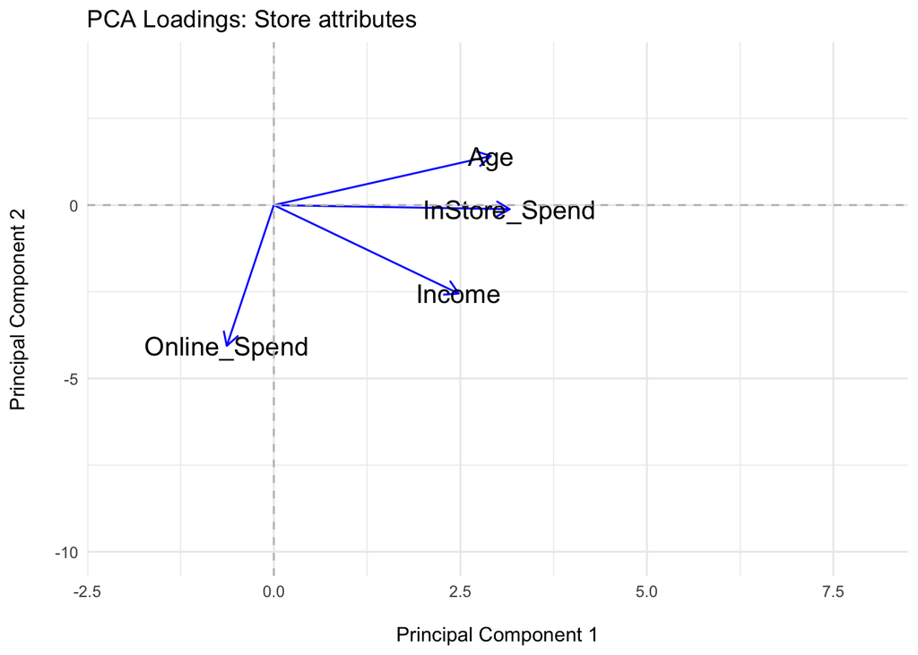

```r
#plot loadings
# Scale loadings for better visibility in plots
arrow_scale <- 5   # tweak if arrows are too short/long

# Plot loadings alone (annotated with variables names)
p_loadings <- ggplot(pca_loadings, aes(x = PC1 * arrow_scale, y = PC2 * arrow_scale, label = variable)) +
  geom_segment(aes(x = 0, y = 0, xend = PC1 * arrow_scale, yend = PC2 * arrow_scale),
               arrow = arrow(length = unit(0.3, "cm")), color = "blue") +
  geom_text(size = 5) +
  labs(
    title = "PCA Loadings: Store attributes",
    x = "\nPrincipal Component 1",
    y = "Principal Component 2\n"
  ) +
  geom_vline(xintercept = 0, linetype = "dashed", color = "gray") +
  geom_hline(yintercept = 0, linetype = "dashed", color = "gray") +
  theme_minimal() +
  coord_cartesian(xlim = c(-2, 8), ylim = c(-10, 4))  # adjust as needed
p_loadings
```

- Do the directions of the arrow align with you previous description of the PCs? (Interpretation tip: A long arrow toward PC1+ means that variable increases as you move right; toward PC2+ means it increases as you move up. Opposite directions imply negative association with that PC.)

**SOLUTION** Yes: PC1 contrasts high in-store spend, age, income vs low; PC2 contrasts high online spend vs low.

### 7.3 Plot PCA scores with clusters

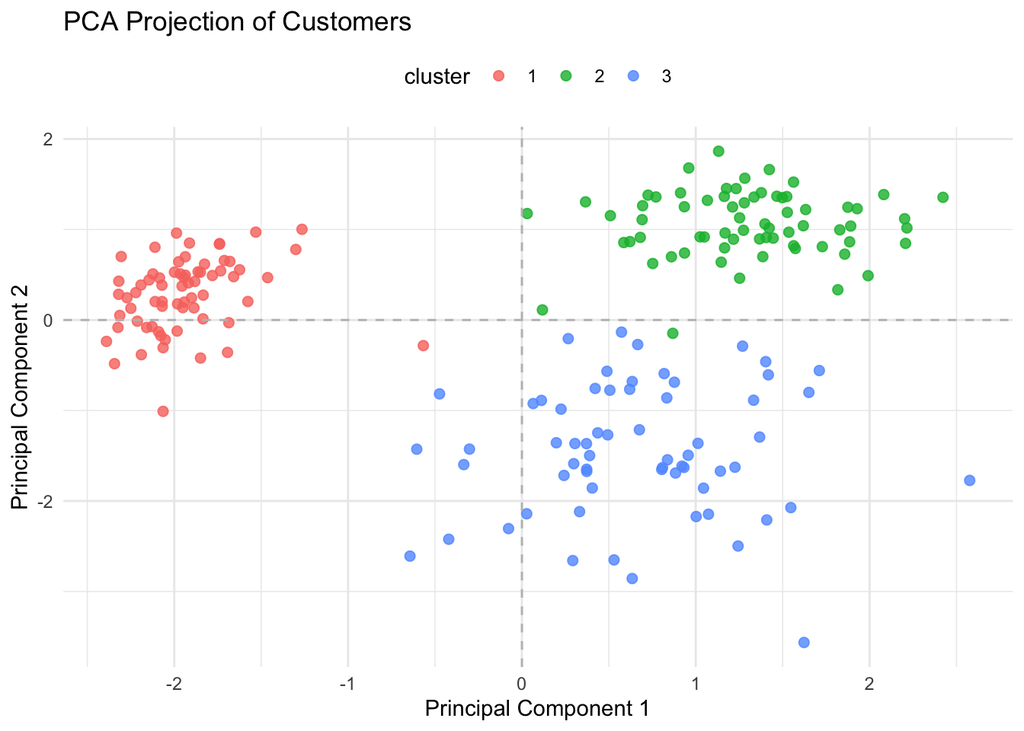

```r
# plot the PCA scores with clusters
ggplot(pca_data, aes(PC1, PC2, color = cluster)) +
  geom_point(size = 2, alpha = 0.8) +
  labs(title = "PCA Projection of Customers",
       x = "Principal Component 1",
       y = "Principal Component 2") +
  geom_vline(xintercept = 0, linetype = "dashed", color = "gray") +
  geom_hline(yintercept = 0, linetype = "dashed", color = "gray") +
  theme_minimal() +
  theme(legend.position = "top")
```

- Do clusters separate cleanly in the first two PCs?

**SOLUTION** Yes—first two PCs (largely spend contrasts) separate the three groups visually.

### 7.4 PCA Biplot (Scores + Loadings)

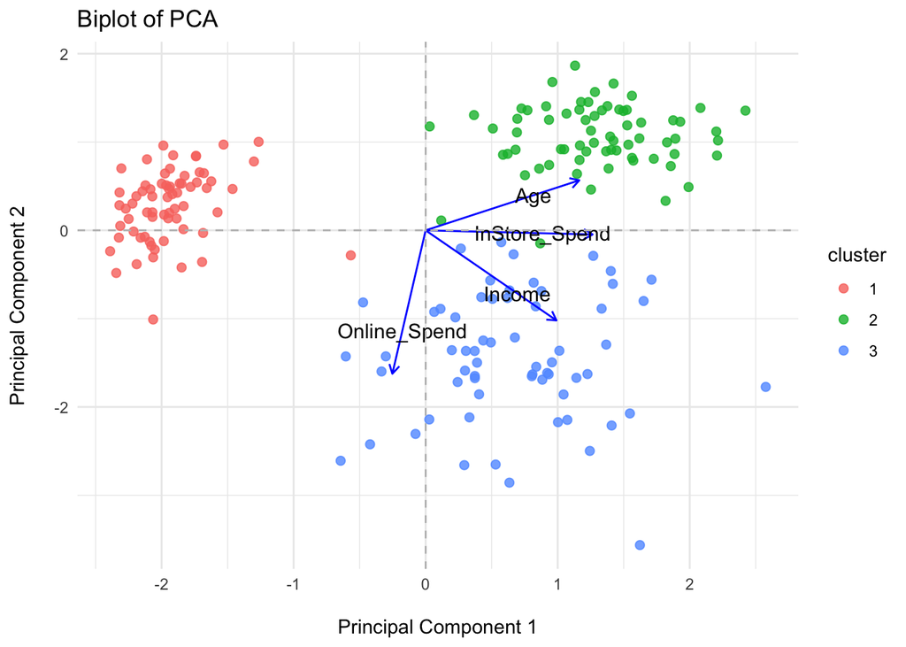

```r
arrow_scale <- 2   # tweak if arrows are too short/long

biplot <- ggplot() +
  geom_point(data = pca_data, aes(x = PC1, y = PC2, color = cluster), size = 2, alpha = 0.8) +
  geom_segment(data = pca_loadings,
               aes(x = 0, y = 0, xend = PC1*arrow_scale, yend = PC2*arrow_scale),
               arrow = arrow(length = unit(0.2, "cm")),
               color = "blue") +
  geom_text(data = pca_loadings,
            aes(x = PC1 * 1.4, y = PC2 * 1.4, label = variable),
            size = 4) +
  labs(
    title = "Biplot of PCA",
    x = "\nPrincipal Component 1",
    y = "Principal Component 2\n"
  ) +
  geom_vline(xintercept = 0, linetype = "dashed", color = "gray") +
  geom_hline(yintercept = 0, linetype = "dashed", color = "gray") +
  theme_minimal()
biplot
```

- How do the clusters relate to the original features based on the biplot? Do you see a correspondence with the clustering means table above (part 6)?

- Now that you performed the whole clustering analysis, answer the following questions:
  - Which cluster looks most valuable?
  - What marketing actions would you take for each segment? (e.g., how would you target them? how? what offers?)

**SOLUTION** Omni-channel (high both) likely most valuable (cross-sell, loyalty). Online-heavy: digital promotions; In-store-heavy: local offers/merchandising.